# Part II - Prosper Loans Data Exploration

## by Marshal Ruzvidzo

## Investigation Overview

In the exploration process the main variable of interest was BorrowerAPR, which is the total annual amount paid towards the loan. In the exploration attempted to find the relationship between the Borrower APR and other variables of interest

## Dataset Overview

The data consisted of 113937 loans and 81 variables. The main variables that were explored included:

1. BorrowerAPR
2. Term
3. ListingCategory (numeric)
4. CreditScoreRangeUpper
5. LoanOriginalAmount
6. IncomeRange
7. DebtToIncomeRatio.

## The distribution of loan listed categories

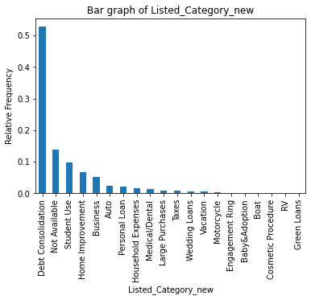

## The relationship between Borrower APR and CreditScoreRangeUpper

The data set shows that the CreditScoreRangeUpper increases the BorrowerAPR decreases. Hence if someone has higher credit score he is likely to pay a lower borrower APR compared to those with lower credit scores.

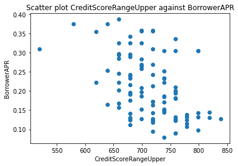

## The relationship between Borrower APR , DebtToIncomeRatio and Term

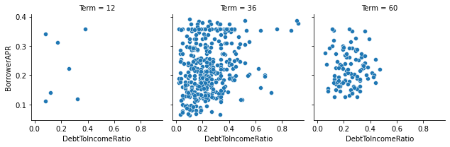

## The distribution of BorrowerAPR, LoanOriginalAmount and IncomeRange

The LoanOrginalAmount increases as the BorrowerAPR decreases across all income ranges. This is expected because as the borrower APR is paid annually so over a long period the borrower APR annualpayments accumulates.

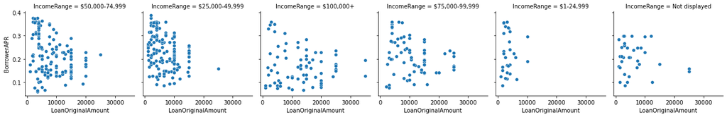